# R Notebook

### Stepwise regression

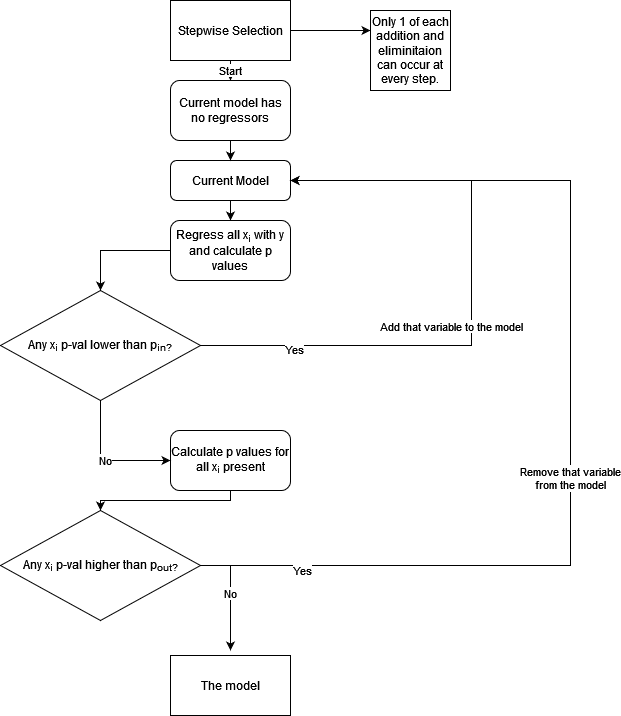

## Part B

Model validation may not be mentioned alot in papers but its a must have component of model building as it is the process of making sure that model works and can be used in real life.

## Part C

- Gender
- Age
- n.projects
- Graduation.CGPA
- haslover
- personality
- enthusiasm
- living.place
- living.conditions.score
- monthly.earnings
- has.necessary.equipment
- disability.severity

## Part D

Thats because we want to be adding variables less often than we remove them. If the p value for the entry is higher than p value for removal then that means we will needlessly increase the size of the model with not so good variables.

# Q3

```r
train <- read.xlsx("./job_model_building_data.xlsx")
test <- read.xlsx("./job_validation_data.xlsx")

head(train)
```

|  | x1 | x2 | x3 | x4 | y |
| --- | --- | --- | --- | --- | --- |
| 1 | 86 | 110 | 100 | 87 | 88 |
| 2 | 62 | 97 | 99 | 100 | 80 |
| 3 | 110 | 107 | 103 | 103 | 96 |
| 4 | 101 | 117 | 93 | 95 | 76 |
| 5 | 100 | 101 | 95 | 88 | 80 |
| 6 | 78 | 85 | 95 | 84 | 73 |

```r
head(test)
```

[output not shown]

## Part A

```r
pairs(train)

corrplot(cor(train %>% select(-y)))
```

[output not shown]

x3 & x4 seems to be highly correlated, there may be multicolinearity problem. Also in the plots, y~x3 and y~x4 looks near identical.

```r
vif(lm(y~., data=train))
```

[output not shown]

These vif values are not that high. But if we wanted to be more conservative we could drop either x3 or x4.

## Part B

```r
model.new <- lm(y~., data=train)

summary(model.new)
```

[output not shown]

To me it seems like x2 should be dropped. That is because 0 is within the confidence interval.

## Part C

```r
number.of.predictors <- 4
predictor.names <- colnames(train)[1:number.of.predictors]
ind <- expand.grid(c(1,0), c(1,0), c(1,0), c(1,0))
c <- c()
for(i in 1:nrow(ind)){
c[i] <- paste(predictor.names[as.logical(ind[i,])], collapse="+")
}
c[16] <- 1
c <- c[order(nchar(c))]
c <- paste("y ~", c)
all <- data.frame(formula=rep(NA, 16), rsq.p= rep(NA, 16))
for(i in 1:length(c)){
    all$formula[i] <- c[i]
    all$rsq.p[i] <- summary(lm(as.formula(c[i]), data=train))$adj.r.squared
}
```

```r
all$p <- c(1,2,2,2,2,3,3,3,3,3,3,4,4,4,4,5)
all
```

[output not shown]

```r
max.rsq <- group_by(all, p) %>% summarize(max.rsq=max(rsq.p))
ggplot(all, aes(p, rsq.p)) + geom_point() + ylab("R2.adj(p)") +
  geom_line(data= max.rsq, aes(p,max.rsq))
```

[output not shown]

When the formula is *y = x1 + x3 + x4* the $R^2_{adj}$ has the highest value.

## Part D

```r
model <- lm(y~., data=train)
ols_step_both_p(model, pent = 0.05, prem = 0.1)$model
```

[output not shown]

## Part E

They are the same..

## Part F

```r
model.new <- lm(y~.-x2, train)
PRESS <- function(model){
  i <- residuals(model)/(1 - lm.influence(model)$hat)
  sum(i^2)
}
PRESS(model.new)
```

[output not shown]

```r
sse <- sum((model.new$fitted.values - train$y)**2)
sse

mse <- sse/(nrow(train)-1)
```

[output not shown]

## Part G

```r
par(mfrow=c(1,2))
corrplot(cor(train %>% select(-y)), type="upper", title = "Train")
corrplot(cor(test %>% select(-y)), type="upper", title = "Test")
```

[output not shown]

corplots are near identical with the sole difference being correlation of x2~x4

## Part H

```r
summary(lm(y~.-x2, test))

summary(model.new)
```

[output not shown]

As we can see the values are near identical. This means the model has high chance to work with new data. It is useful.

## Part I

```r
mspe <- sum((predict(model.new, test %>%
                       select(-y), type="response")-test$y)**2)/(nrow(test)-1)

mspe
mse
```

[output not shown]

mean squared errors are close also.

## Part J

```r
df <- rbind(train, test)
model.full <- lm(y~.-x2, df)

summary(model.new)$coefficients[,'Std. Error']

data.frame(train = summary(model.new)$coefficients[,'Std. Error'],
           full = summary(model.full)$coefficients[,'Std. Error'])
```

[output not shown]

All standard deviations are lower, although not that much.